# working

# Survey questions

### Q1. Before receiving this survey, did you know influenza is different from the stomach flu?

```r
# all
with(data, table(Q1))
```

```
## Q1
##      No Refused     Yes
##     488      16    1664
```

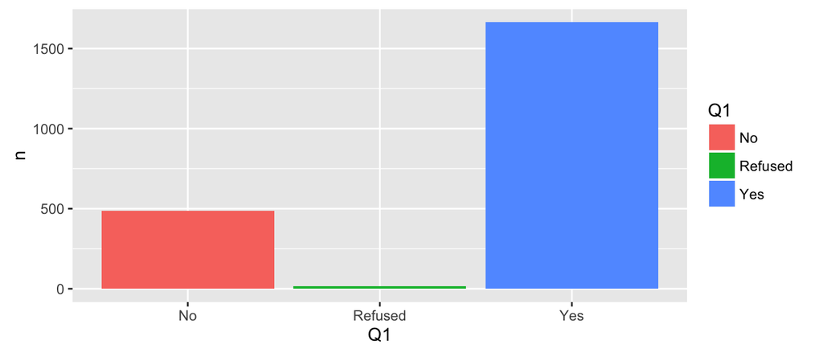

```r
q1 <- data %>%
  group_by(Q1) %>%
  count(Q1)
ggplot(q1, aes(x = Q1, y = n, fill = Q1)) + geom_bar(stat = 'identity')
```

```r
# by gender
with(data, table(Q1, PPGENDER))
```

```
##          PPGENDER
## Q1        Female Male
##   No         205  283
##   Refused      4   12
##   Yes        888  776
```

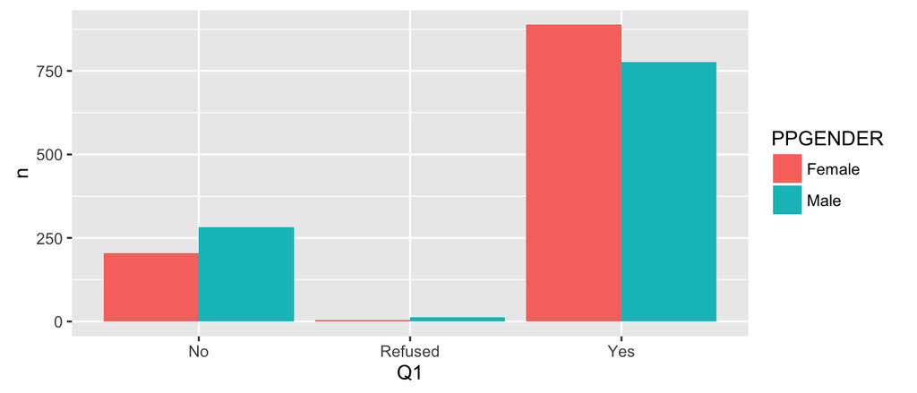

```r
q1 <- data %>%
  group_by(Q1, PPGENDER) %>%
  count(Q1, PPGENDER)
ggplot(q1, aes(x = Q1, y = n, fill = PPGENDER)) +
  geom_bar(stat = 'identity', position = position_dodge())
```

```r
# by ethnicity
with(data, table(Q1, PPETHM))
```

```
##          PPETHM
## Q1        2+ Races, Non-Hispanic Black, Non-Hispanic Hispanic
##   No                          18                  50       69
##   Refused                      0                   2        2
##   Yes                         62                 143      161
##          PPETHM
## Q1        Other, Non-Hispanic White, Non-Hispanic
##   No                       29                 322
##   Refused                   1                  11
##   Yes                      63                1235
```

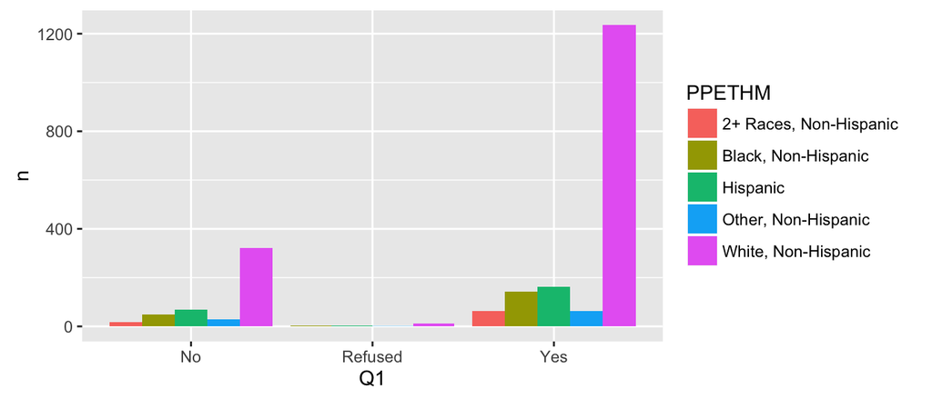

```r
q1 <- data %>%
  group_by(Q1, PPETHM) %>%
  count(Q1, PPETHM)
ggplot(q1, aes(x = Q1, y = n, fill = PPETHM)) +
  geom_bar(stat = 'identity', position = position_dodge())
```

```r
# by income
with(data, table(Q1, PPINCIMP))
```

```
##          PPINCIMP
## Q1        $10,000 to $12,499 $100,000 to $124,999 $12,500 to $14,999
##   No                      17                   56                 10
##   Refused                  0                    2                  0
##   Yes                     39                  269                 38
##          PPINCIMP
## Q1        $125,000 to $149,999 $15,000 to $19,999 $150,000 to $174,999
##   No                        24                 22                   16
##   Refused                    0                  1                    1
##   Yes                      108                 40                   68
##          PPINCIMP
## Q1        $175,000 or more $20,000 to $24,999 $25,000 to $29,999
##   No                    18                 16                 23
##   Refused                1                  2                  0
##   Yes                  107                 55                 76
##          PPINCIMP
## Q1        $30,000 to $34,999 $35,000 to $39,999 $40,000 to $49,999
##   No                      21                 31                 42
##   Refused                  2                  1                  0
##   Yes                     70                 72                107
##          PPINCIMP
## Q1        $5,000 to $7,499 $50,000 to $59,999 $60,000 to $74,999
##   No                     8                 46                 50
##   Refused                1                  1                  2
##   Yes                   16                137                172
##          PPINCIMP
## Q1        $7,500 to $9,999 $75,000 to $84,999 $85,000 to $99,999
##   No                     7                 26                 33
##   Refused                0                  1                  0
##   Yes                    7                133                120
##          PPINCIMP
## Q1        Less than $5,000
##   No                    22
##   Refused                1
##   Yes                   30
```

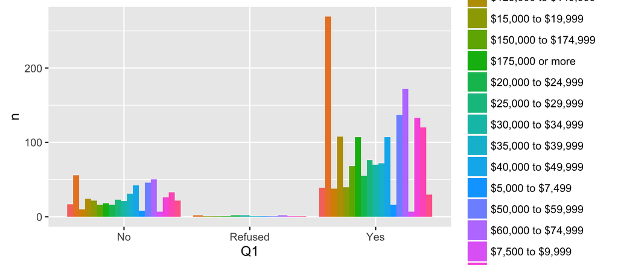

```r
q1 <- data %>%
  group_by(Q1, PPINCIMP) %>%
  count(Q1, PPINCIMP)
ggplot(q1, aes(x = Q1, y = n, fill = PPINCIMP)) +
  geom_bar(stat = 'identity', position = position_dodge())
```

### Q2. Have you had an illness with influenza like symptoms since August 2015?

```r
# all
with(data, table(Q2))
```

```
## Q2
##      No Refused     Yes
##    1735      19     414
```

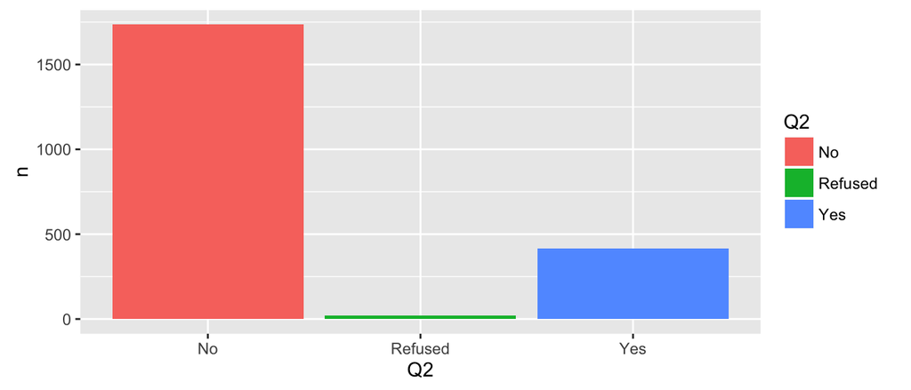

```r
q2 <- data %>%
  group_by(Q2) %>%
  count(Q2)
ggplot(q2, aes(x = Q2, y = n, fill = Q2)) + geom_bar(stat = 'identity')
```

```r
# by gender
with(data, table(Q2, PPGENDER))
```

```
##          PPGENDER
## Q2        Female Male
##   No         858  877
##   Refused      5   14
##   Yes        234  180
```

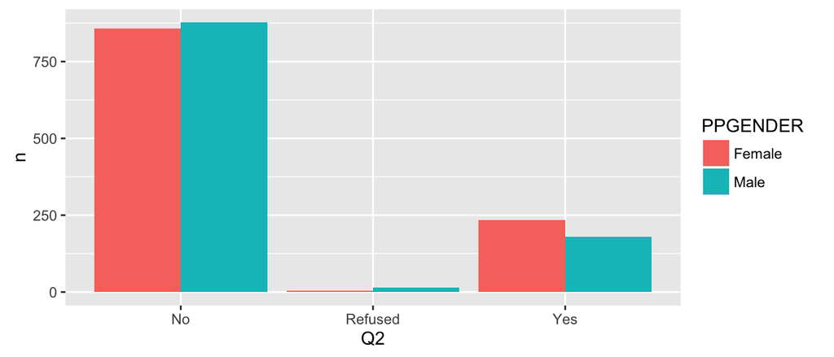

```r
q2 <- data %>%
  group_by(Q2, PPGENDER) %>%
  count(Q2, PPGENDER)
ggplot(q2, aes(x = Q2, y = n, fill = PPGENDER)) +
  geom_bar(stat = 'identity', position = position_dodge())
```

```r
# by ethnicity
with(data, table(Q2, PPETHM))
```

```
##          PPETHM
## Q2        2+ Races, Non-Hispanic Black, Non-Hispanic Hispanic
##   No                          61                 152      164
##   Refused                      0                   4        3
##   Yes                         19                  39       65
##          PPETHM
## Q2        Other, Non-Hispanic White, Non-Hispanic
##   No                       71                1287
##   Refused                   0                  12
##   Yes                      22                 269
```

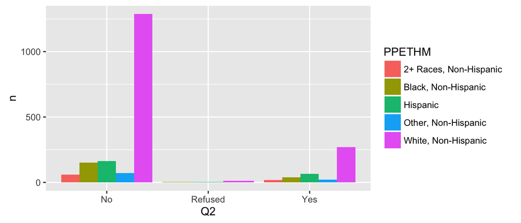

```r
q2 <- data %>%
  group_by(Q2, PPETHM) %>%
  count(Q2, PPETHM)
ggplot(q2, aes(x = Q2, y = n, fill = PPETHM)) +
  geom_bar(stat = 'identity', position = position_dodge())
```

```r
# by income
with(data, table(Q2, PPINCIMP))
```

```
##          PPINCIMP
## Q2        $10,000 to $12,499 $100,000 to $124,999 $12,500 to $14,999
##   No                      38                  265                 39
##   Refused                  1                    1                  0
##   Yes                     17                   61                  9
##          PPINCIMP
## Q2        $125,000 to $149,999 $15,000 to $19,999 $150,000 to $174,999
##   No                       112                 46                   62
##   Refused                    0                  2                    2
##   Yes                       20                 15                   21
##          PPINCIMP
## Q2        $175,000 or more $20,000 to $24,999 $25,000 to $29,999
##   No                   104                 55                 79
##   Refused                1                  1                  1
##   Yes                   21                 17                 19
##          PPINCIMP
## Q2        $30,000 to $34,999 $35,000 to $39,999 $40,000 to $49,999
##   No                      74                 85                121
##   Refused                  1                  1                  1
##   Yes                     18                 18                 27
##          PPINCIMP
## Q2        $5,000 to $7,499 $50,000 to $59,999 $60,000 to $74,999
##   No                    19                155                172
##   Refused                0                  2                  2
##   Yes                    6                 27                 50
##          PPINCIMP
## Q2        $7,500 to $9,999 $75,000 to $84,999 $85,000 to $99,999
##   No                    13                130                123
##   Refused                0                  1                  1
##   Yes                    1                 29                 29
##          PPINCIMP
## Q2        Less than $5,000
##   No                    43
##   Refused                1
##   Yes                    9
```

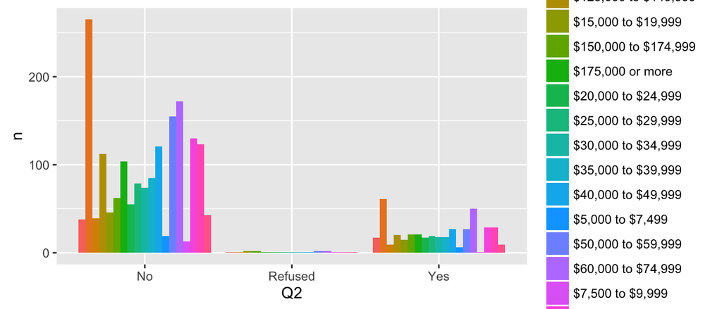

```r
q2 <- data %>%
  group_by(Q2, PPINCIMP) %>%
  count(Q2, PPINCIMP)
ggplot(q2, aes(x = Q2, y = n, fill = PPINCIMP)) +
  geom_bar(stat = 'identity', position = position_dodge())
```

### Q3. Has any other person in your household had an illness with influenza like symptoms since August 2015?

```
## Q3
## Don_t know         No    Refused        Yes
##        161       1608         16        383
```

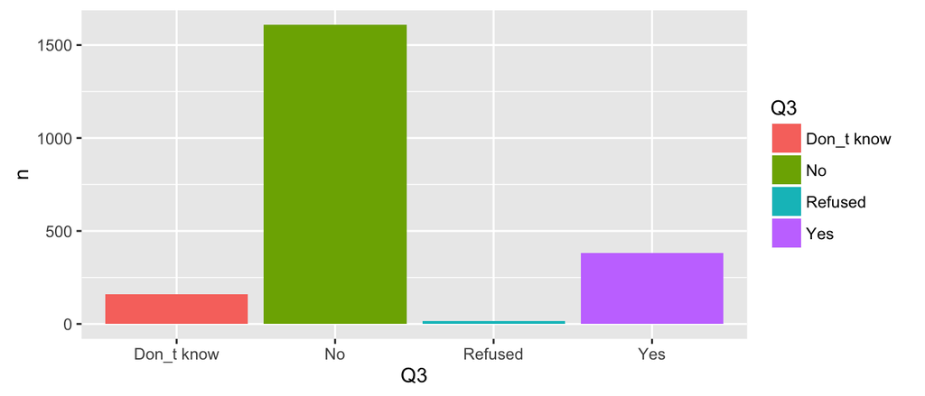

```
##             PPGENDER
## Q3           Female Male
##   Don_t know     72   89
##   No            804  804
##   Refused         4   12
##   Yes           217  166
```

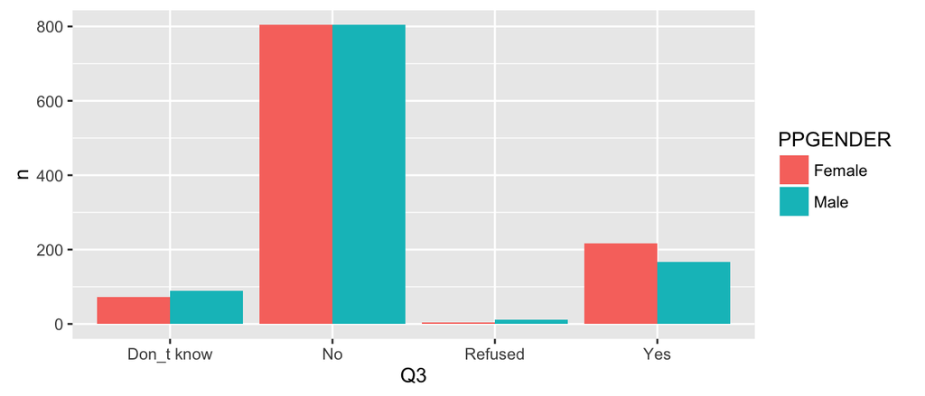

```
##             PPETHM
## Q3           2+ Races, Non-Hispanic Black, Non-Hispanic Hispanic
##   Don_t know                      6                  19       30
##   No                             57                 149      146
##   Refused                         0                   2        3
##   Yes                            17                  25       53
##             PPETHM
## Q3           Other, Non-Hispanic White, Non-Hispanic
##   Don_t know                  11                  95
##   No                          59                1197
##   Refused                      0                  11
##   Yes                         23                 265
```

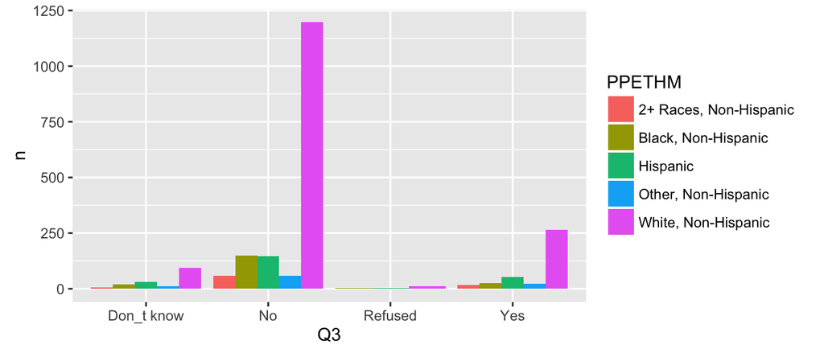

```
##             PPINCIMP
## Q3           $10,000 to $12,499 $100,000 to $124,999 $12,500 to $14,999
##   Don_t know                  4                   20                  7
##   No                         44                  245                 30
##   Refused                     0                    1                  0
##   Yes                         8                   61                 11
##             PPINCIMP
## Q3           $125,000 to $149,999 $15,000 to $19,999 $150,000 to $174,999
##   Don_t know                    6                  7                    3
##   No                          100                 47                   58
##   Refused                       0                  1                    1
##   Yes                          26                  8                   23
##             PPINCIMP
## Q3           $175,000 or more $20,000 to $24,999 $25,000 to $29,999
##   Don_t know                7                  8                  4
##   No                       94                 52                 81
##   Refused                   1                  1                  1
##   Yes                      24                 12                 13
##             PPINCIMP
## Q3           $30,000 to $34,999 $35,000 to $39,999 $40,000 to $49,999
##   Don_t know                 11                 11                  6
##   No                         70                 75                117
##   Refused                     3                  1                  1
##   Yes                         9                 17                 25
##             PPINCIMP
## Q3           $5,000 to $7,499 $50,000 to $59,999 $60,000 to $74,999
##   Don_t know                6                 13                 18
##   No                       18                136                165
##   Refused                   0                  2                  2
##   Yes                       1                 33                 39
##             PPINCIMP
## Q3           $7,500 to $9,999 $75,000 to $84,999 $85,000 to $99,999
##   Don_t know                1                  7                 11
##   No                       13                120                107
##   Refused                   0                  0                  0
##   Yes                       0                 33                 35
##             PPINCIMP
## Q3           Less than $5,000
##   Don_t know               11
##   No                       36
##   Refused                   1
##   Yes                       5
```

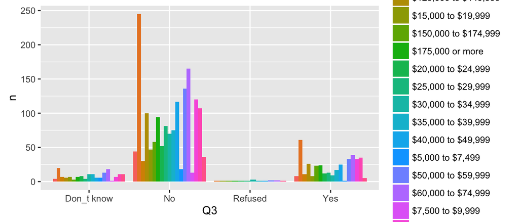

### Q4. Does your job require you to have a lot of contact with the public?

```
## Q4
##                                         No, I don_t work
##                                                      779
## No, my job does not require much contact with the public
##                                                      620
##                                                  Refused
##                                                       18
##                                                      Yes
##                                                      751
```

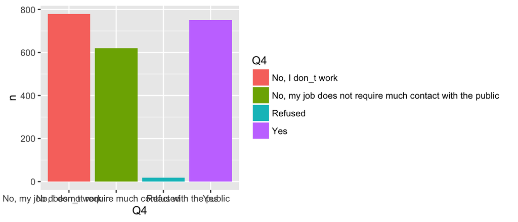

```
##                                                           PPGENDER
## Q4                                                         Female Male
##   No, I don_t work                                            430  349
##   No, my job does not require much contact with the public    263  357
##   Refused                                                       4   14
##   Yes                                                         400  351
```

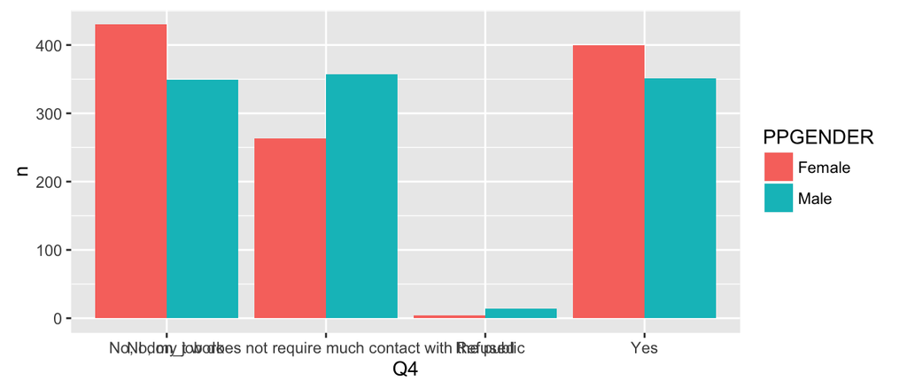

```
##                                                           PPETHM
## Q4                                                         2+ Races, Non-Hispanic
##   No, I don_t work                                                             30
##   No, my job does not require much contact with the public                     23
##   Refused                                                                       0
##   Yes                                                                          27
##                                                           PPETHM
## Q4                                                         Black, Non-Hispanic
##   No, I don_t work                                                          69
##   No, my job does not require much contact with the public                  59
##   Refused                                                                    3
##   Yes                                                                       64
##                                                           PPETHM
## Q4                                                         Hispanic
##   No, I don_t work                                               69
##   No, my job does not require much contact with the public       72
##   Refused                                                         4
##   Yes                                                            87
##                                                           PPETHM
## Q4                                                         Other, Non-Hispanic
##   No, I don_t work                                                          24
##   No, my job does not require much contact with the public                  34
##   Refused                                                                    0
##   Yes                                                                       35
##                                                           PPETHM
## Q4                                                         White, Non-Hispanic
##   No, I don_t work                                                         587
##   No, my job does not require much contact with the public                 432
##   Refused                                                                   11
##   Yes                                                                      538
```

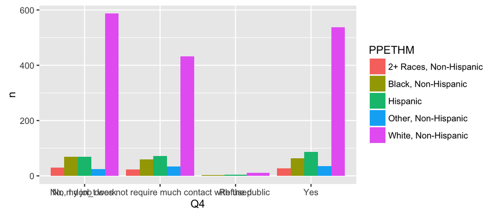

```
##                                                           PPINCIMP
## Q4                                                         $10,000 to $12,499
##   No, I don_t work                                                         33
##   No, my job does not require much contact with the public                  7
##   Refused                                                                   1
##   Yes                                                                      15
##                                                           PPINCIMP
## Q4                                                         $100,000 to $124,999
##   No, I don_t work                                                           87
##   No, my job does not require much contact with the public                  111
##   Refused                                                                     2
##   Yes                                                                       127
##                                                           PPINCIMP
## Q4                                                         $12,500 to $14,999
##   No, I don_t work                                                         32
##   No, my job does not require much contact with the public                  5
##   Refused                                                                   0
##   Yes                                                                      11
##                                                           PPINCIMP
## Q4                                                         $125,000 to $149,999
##   No, I don_t work                                                           39
##   No, my job does not require much contact with the public                   51
##   Refused                                                                     0
##   Yes                                                                        42
##                                                           PPINCIMP
## Q4                                                         $15,000 to $19,999
##   No, I don_t work                                                         28
##   No, my job does not require much contact with the public                 13
##   Refused                                                                   1
##   Yes                                                                      21
##                                                           PPINCIMP
## Q4                                                         $150,000 to $174,999
##   No, I don_t work                                                           23
##   No, my job does not require much contact with the public                   25
##   Refused                                                                     1
##   Yes                                                                        36
##                                                           PPINCIMP
## Q4                                                         $175,000 or more
##   No, I don_t work                                                       32
##   No, my job does not require much contact with the public               47
```

[output cut: 59 more lines]

```
##   No, my job does not require much contact with the public                 51
##   Refused                                                                   0
##   Yes                                                                      64
##                                                           PPINCIMP
## Q4                                                         $85,000 to $99,999
##   No, I don_t work                                                         47
##   No, my job does not require much contact with the public                 48
##   Refused                                                                   0
##   Yes                                                                      58
##                                                           PPINCIMP
## Q4                                                         Less than $5,000
##   No, I don_t work                                                       29
##   No, my job does not require much contact with the public               17
##   Refused                                                                 1
##   Yes                                                                     6
```

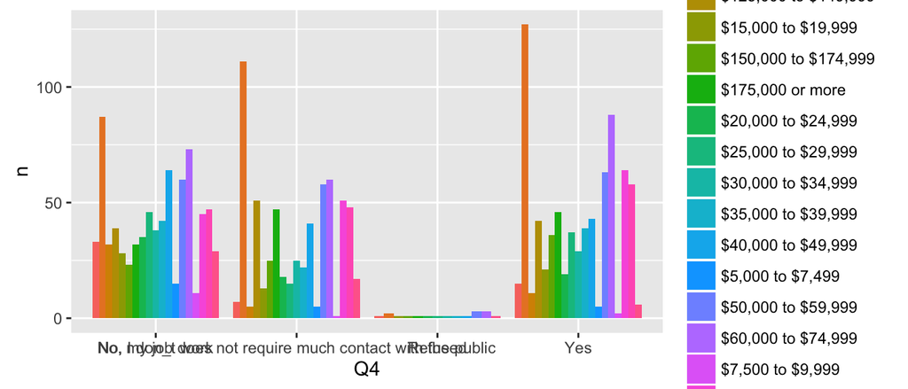

### Q5. Do you have a car that you can use to travel to work?

```
## Q5
##      No Refused     Yes
##     133       3    1235
```

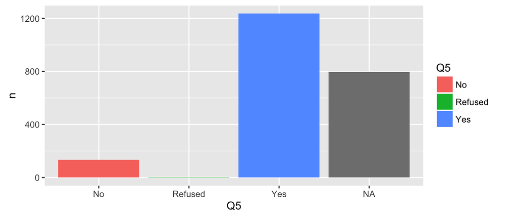

```
##         Q5
## PPGENDER  No Refused Yes
##   Female  70       1 592
##   Male    63       2 643
```

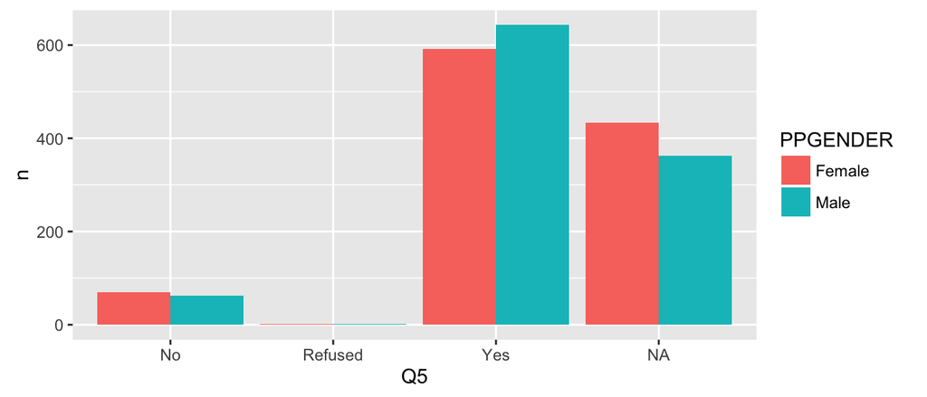

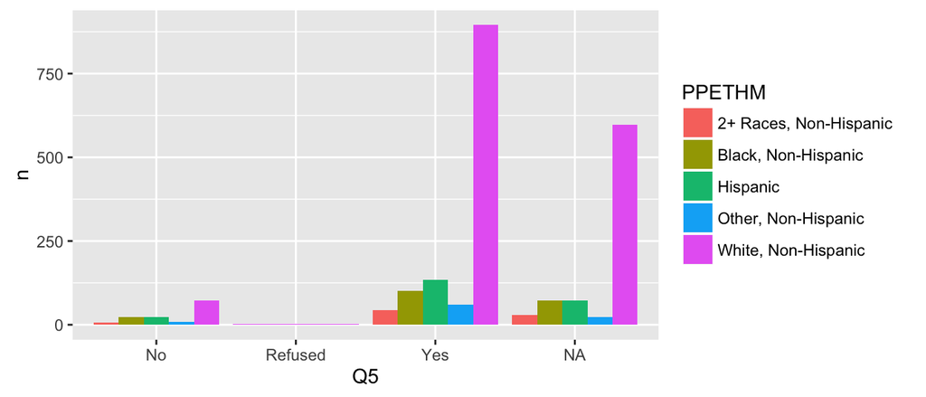

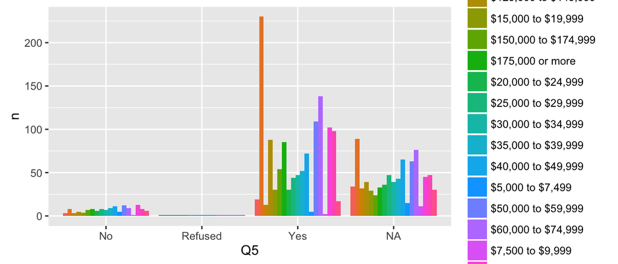

### Q6. Do you regularly use public transportation?

```
## Q6
##      No Refused     Yes
##    1959      15     194
```

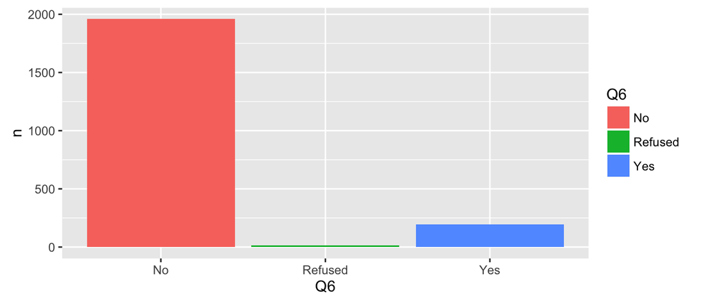

```
## Source: local data frame [6 x 3]
## Groups: Q6 [?]
##
##        Q6 PPGENDER     n
##    (fctr)   (fctr) (int)
## 1      No   Female   998
## 2      No     Male   961
## 3 Refused   Female     3
## 4 Refused     Male    12
## 5     Yes   Female    96
## 6     Yes     Male    98
```

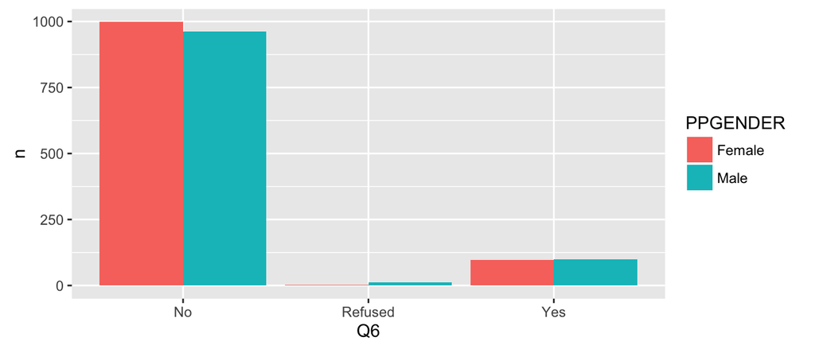

```
## Source: local data frame [13 x 3]
## Groups: Q6 [?]
##
##         Q6                 PPETHM     n
##     (fctr)                 (fctr) (int)
## 1       No 2+ Races, Non-Hispanic    62
## 2       No    Black, Non-Hispanic   158
## 3       No               Hispanic   196
## 4       No    Other, Non-Hispanic    80
## 5       No    White, Non-Hispanic  1463
## 6  Refused    Black, Non-Hispanic     1
## 7  Refused               Hispanic     4
## 8  Refused    White, Non-Hispanic    10
## 9      Yes 2+ Races, Non-Hispanic    18
## 10     Yes    Black, Non-Hispanic    36
## 11     Yes               Hispanic    32
## 12     Yes    Other, Non-Hispanic    13
## 13     Yes    White, Non-Hispanic    95
```

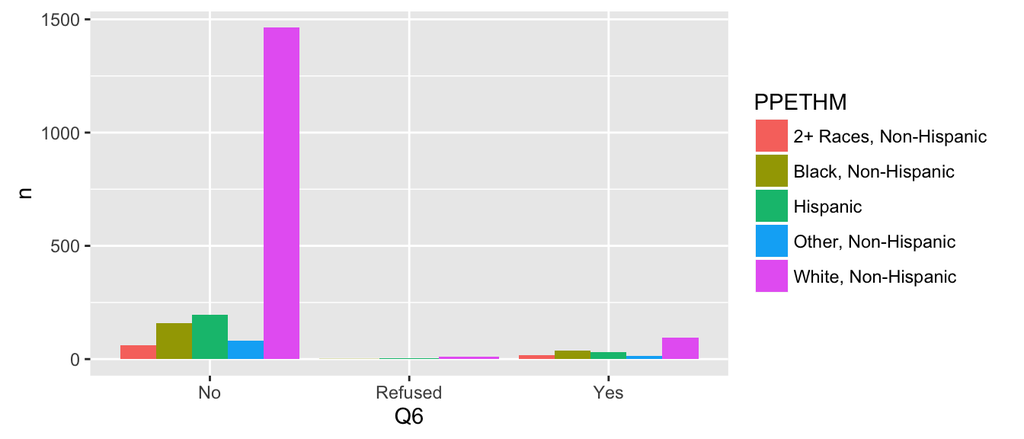

```
## Source: local data frame [50 x 3]
## Groups: Q6 [?]
##
##        Q6             PPINCIMP     n
##    (fctr)               (fctr) (int)
## 1      No   $10,000 to $12,499    47
## 2      No $100,000 to $124,999   305
## 3      No   $12,500 to $14,999    42
## 4      No $125,000 to $149,999   123
## 5      No   $15,000 to $19,999    58
## 6      No $150,000 to $174,999    74
## 7      No     $175,000 or more   108
## 8      No   $20,000 to $24,999    64
## 9      No   $25,000 to $29,999    90
## 10     No   $30,000 to $34,999    85
## ..    ...                  ...   ...
```

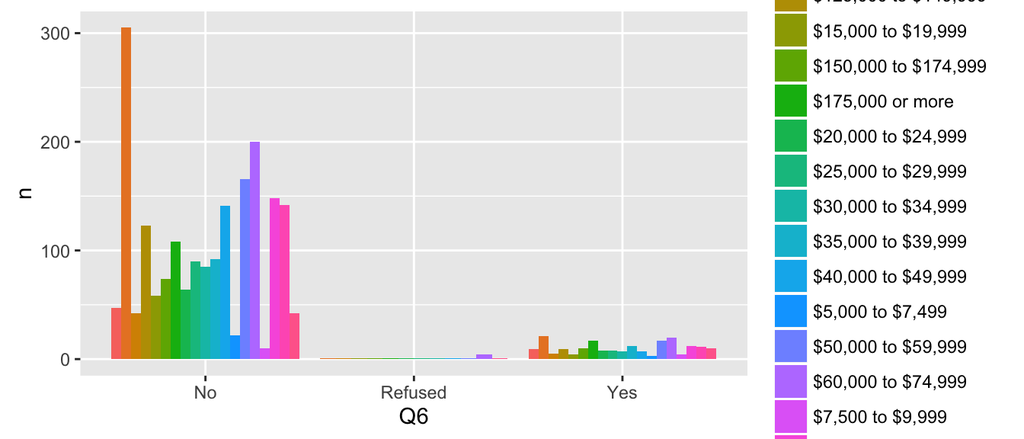

### Q7. What types of public transportation do you regularly use?

```
##                r
## q                No Yes
##   Q7_1_Bus       57 137
##   Q7_2_Carpool  184  10
##   Q7_3_Subway   131  63
##   Q7_4_Train    139  55
##   Q7_5_Taxi     169  25
##   Q7_6_Airplane 175  19
##   Q7_7_Other    179  15
```

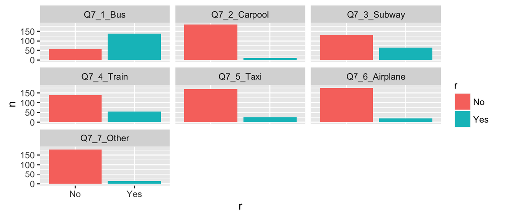

```
## Source: local data frame [42 x 4]
## Groups: PPGENDER, q [?]
##
##    PPGENDER            q     r     n
##      (fctr)        (chr) (chr) (int)
## 1    Female     Q7_1_Bus    No    27
## 2    Female     Q7_1_Bus   Yes    69
## 3    Female     Q7_1_Bus    NA  1001
## 4    Female Q7_2_Carpool    No    91
## 5    Female Q7_2_Carpool   Yes     5
## 6    Female Q7_2_Carpool    NA  1001
## 7    Female  Q7_3_Subway    No    68
## 8    Female  Q7_3_Subway   Yes    28
## 9    Female  Q7_3_Subway    NA  1001
## 10   Female   Q7_4_Train    No    75
## ..      ...          ...   ...   ...
```

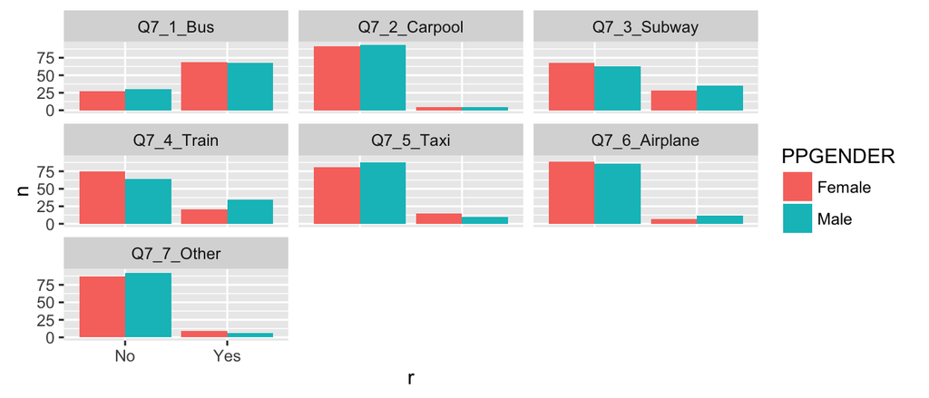

```
## Source: local data frame [100 x 4]
## Groups: PPETHM, q [?]
##
##                    PPETHM            q     r     n
##                    (fctr)        (chr) (chr) (int)
## 1  2+ Races, Non-Hispanic     Q7_1_Bus    No     4
## 2  2+ Races, Non-Hispanic     Q7_1_Bus   Yes    14
## 3  2+ Races, Non-Hispanic     Q7_1_Bus    NA    62
## 4  2+ Races, Non-Hispanic Q7_2_Carpool    No    18
## 5  2+ Races, Non-Hispanic Q7_2_Carpool    NA    62
## 6  2+ Races, Non-Hispanic  Q7_3_Subway    No    12
## 7  2+ Races, Non-Hispanic  Q7_3_Subway   Yes     6
## 8  2+ Races, Non-Hispanic  Q7_3_Subway    NA    62
## 9  2+ Races, Non-Hispanic   Q7_4_Train    No    15
## 10 2+ Races, Non-Hispanic   Q7_4_Train   Yes     3
## ..                    ...          ...   ...   ...
```

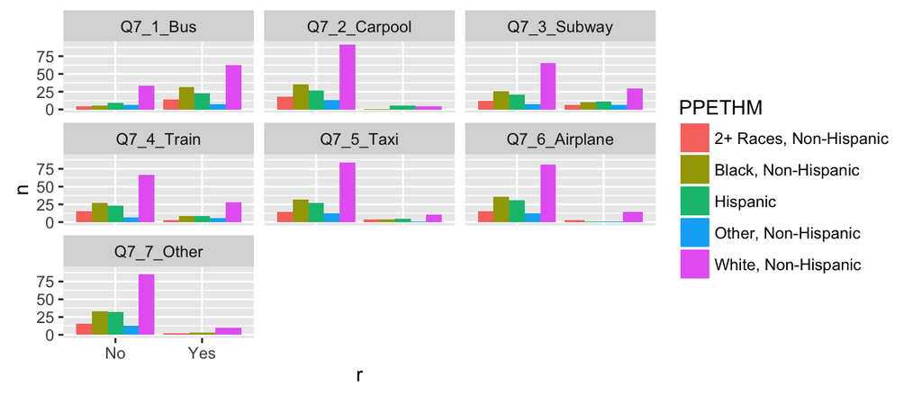

```
## Source: local data frame [357 x 4]
## Groups: PPINCIMP, q [?]
##
##              PPINCIMP            q     r     n
##                (fctr)        (chr) (chr) (int)
## 1  $10,000 to $12,499     Q7_1_Bus    No     3
## 2  $10,000 to $12,499     Q7_1_Bus   Yes     6
## 3  $10,000 to $12,499     Q7_1_Bus    NA    47
## 4  $10,000 to $12,499 Q7_2_Carpool    No     9
## 5  $10,000 to $12,499 Q7_2_Carpool    NA    47
## 6  $10,000 to $12,499  Q7_3_Subway    No     9
## 7  $10,000 to $12,499  Q7_3_Subway    NA    47
## 8  $10,000 to $12,499   Q7_4_Train    No     8
## 9  $10,000 to $12,499   Q7_4_Train   Yes     1
## 10 $10,000 to $12,499   Q7_4_Train    NA    47
## ..                ...          ...   ...   ...
```

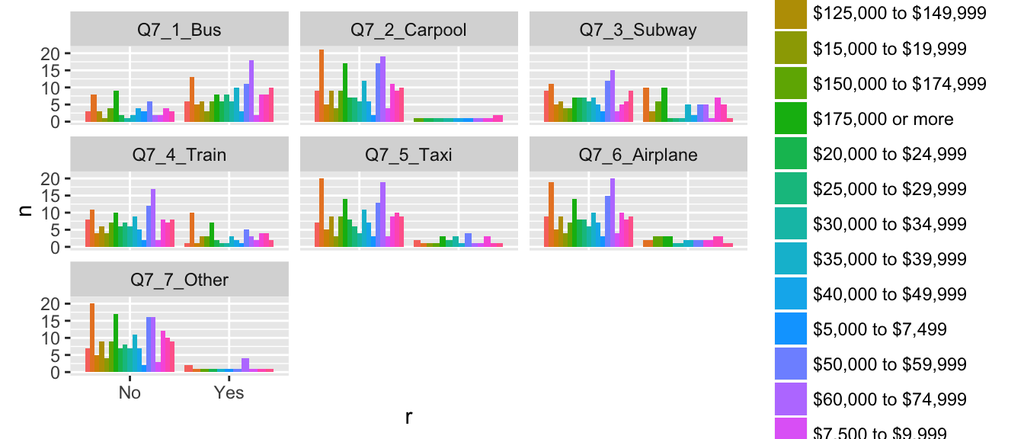